# Linkedin data assessment

Librerie

```r
library(dplyr)
library(ggplot2)
library(grid)
library(gridExtra)
library(tidyverse)
```

### Descrizione del dataset

avg_n_pos_per_prev_tenure : numero medio di posizioni occupate negli incarichi precedenti float

aveg_prev_tenure_len : durata media degli incarichi precedenti float

avg_pos_len : la media della durata di ciascuna posizione ricoperta all’interno dell’azienda attuale float

tenure_len : la durata complessiva di tutte le posizioni ricoperte all’interno dell’azienda float

n_prev_tenures : numero di incarichi precedentemente ottenuti integer

n_pos : numero delle posizioni ricoperte all’interno dell’azienda attuale integer

m_urn : identificativo dell’utente string

avg_prev_tenure_len : ?

c_name : nome dell’azienda string

age : età dell’utente integer

beauty : percentuale di bellezza. Se l’utente è uomo corrisponde al valore di beauty_male, mentre se è donna corrisponde al valore di beauty_female. float

beauty_male : percentuale di bellezza maschile dell’utente. float

beauty_female : percentuale di bellezza femminile dell’utente. float

blur : sfocatura dell’immagine integer

blur_gaussian : ? integer

blur_motion : ? integer

emo_anger : valore associato alla rabbia espressa nell’immagine integer

emo_disgust : valore associato al disgusto espresso nell’immagine integer

emo_fear : valore associato alla paura espressa nell’immagine integer

emo_happines : valore associato alla felicità espressa nell’immagine integer

emo_neutrale : valore associato alla neutralità dell’espressione integer

emo_sadness : valore associato alla tristezza espressa nell’immagine integer

emo_surprise : valore associato alla sorpresa espressa nell’immagine integer

ethnicity : etnia dell’utente string

face_quality : connotati facciali ? float

gender : sesso string

glass : variabile che esprime la presenza o meno di occhiali nella foto string

head_pitch : rotazione della testa rispetto all’asse passante per entrambe le orecchie float

head_roll : rotazione della testa rispetto all’asse perpendicolare al naso float

head_yaw : rotazione della testa rispetto all’asse verticale float

img : url dell’immagine dell’utente string

mouth_close : chiusura della bocca float

mouth_mask : copertura della bocca float

mouth_open : apertura della bocca float

mouth_other : ? float

skin_acne : presenza di acne sulla pelle float

skin_dark_circle : presenza di occhiaie float

skin_health : salute della pelle float

skin_stain : presenza di macchie sulla pelle float

smile : presenza del sorriso float

african : valore associato all’etnia africana visibile in foto float

celtic_english : valore associato all’etnia celtica visibile in foto float

east_asian : valore associato all’etnia est-asiatica visibile in foto float

european : valore associato all’etnia europea visibile in foto float

greek : valore associato all’etnia greca visibile in foto float

hispanic : valore associato all’etnia ispanica visibile in foto float

jewish : valore associato all’etnia ebrea visibile in foto float

muslim : valore associato all’etnia islamica visibile in foto float

nationality : nazionalità string

nordic : valore associato all’etnia nordica visibile in foto float

south_asian : valore associato all’etnia sud-asiatica visibile in foto float

n_followers : numero di seguaci integer

```r
raw_data <- read.csv(file = "linkedin_data.csv")
raw_data
```

| X | avg_n_pos_per_prev_tenure | avg_pos_len | avg_prev_tenure_len | c_name | m_urn | n_pos | n_prev_tenures | tenure_len | age | beauty | beauty_female | beauty_male | blur | blur_gaussian | blur_motion | emo_anger | emo_disgust | emo_fear | emo_happiness | emo_neutral | emo_sadness | emo_surprise | ethnicity | face_quality | gender | glass | head_pitch | head_roll | head_yaw | … |
| --- | --- | --- | --- | --- | --- | --- | --- | --- | --- | --- | --- | --- | --- | --- | --- | --- | --- | --- | --- | --- | --- | --- | --- | --- | --- | --- | --- | --- | --- | --- |
| 0 | 2.000000 | 457.0000 | 1338.00000 | TD | urn:li:member:149435456 | 1 | 1 | 457 | 37 | 57.570 | 63.829 | 57.570 | 0.421 | 0.421 | 0.421 | 0.766 | 0.007 | 0.007 | 99.035 | 0.086 | 0.007 | 0.091 | Asian | 67.662 | Male | Normal | 7.73504830 | -5.195693000 | 12.39454600 | … |
| 1 | 1.500000 | 212.0000 | 897.50000 | Light Up The World (LUTW) | urn:li:member:149435456 | 1 | 2 | 212 | 37 | 57.570 | 63.829 | 57.570 | 0.421 | 0.421 | 0.421 | 0.766 | 0.007 | 0.007 | 99.035 | 0.086 | 0.007 | 0.091 | Asian | 67.662 | Male | Normal | 7.73504830 | -5.195693000 | 12.39454600 | … |
| 2 | 1.333333 | 243.0000 | 669.00000 | Glacier | urn:li:member:149435456 | 1 | 3 | 243 | 37 | 57.570 | 63.829 | 57.570 | 0.421 | 0.421 | 0.421 | 0.766 | 0.007 | 0.007 | 99.035 | 0.086 | 0.007 | 0.091 | Asian | 67.662 | Male | Normal | 7.73504830 | -5.195693000 | 12.39454600 | … |
| 3 | 1.250000 | 123.0000 | 562.50000 | Sprout App | urn:li:member:149435456 | 1 | 4 | 123 | 37 | 57.570 | 63.829 | 57.570 | 0.421 | 0.421 | 0.421 | 0.766 | 0.007 | 0.007 | 99.035 | 0.086 | 0.007 | 0.091 | Asian | 67.662 | Male | Normal | 7.73504830 | -5.195693000 | 12.39454600 | … |
| 4 | 1.200000 | 244.0000 | 474.60000 | College Pro | urn:li:member:149435456 | 1 | 5 | 244 | 37 | 57.570 | 63.829 | 57.570 | 0.421 | 0.421 | 0.421 | 0.766 | 0.007 | 0.007 | 99.035 | 0.086 | 0.007 | 0.091 | Asian | 67.662 | Male | Normal | 7.73504830 | -5.195693000 | 12.39454600 | … |
| 5 | 1.166667 | 304.0000 | 436.16667 | Microsoft | urn:li:member:149435456 | 1 | 6 | 304 | 37 | 57.570 | 63.829 | 57.570 | 0.421 | 0.421 | 0.421 | 0.766 | 0.007 | 0.007 | 99.035 | 0.086 | 0.007 | 0.091 | Asian | 67.662 | Male | Normal | 7.73504830 | -5.195693000 | 12.39454600 | … |
| 6 | 2.000000 | 457.0000 | 1338.00000 | TD | urn:li:member:149435456 | 1 | 1 | 457 | 37 | 57.570 | 63.829 | 57.570 | 0.421 | 0.421 | 0.421 | 0.766 | 0.007 | 0.007 | 99.035 | 0.086 | 0.007 | 0.091 | Asian | 67.662 | Male | Normal | 7.73504830 | -5.195693000 | 12.39454600 | … |
| 7 | 1.500000 | 212.0000 | 897.50000 | Light Up The World (LUTW) | urn:li:member:149435456 | 1 | 2 | 212 | 37 | 57.570 | 63.829 | 57.570 | 0.421 | 0.421 | 0.421 | 0.766 | 0.007 | 0.007 | 99.035 | 0.086 | 0.007 | 0.091 | Asian | 67.662 | Male | Normal | 7.73504830 | -5.195693000 | 12.39454600 | … |
| 8 | 1.333333 | 243.0000 | 669.00000 | Glacier | urn:li:member:149435456 | 1 | 3 | 243 | 37 | 57.570 | 63.829 | 57.570 | 0.421 | 0.421 | 0.421 | 0.766 | 0.007 | 0.007 | 99.035 | 0.086 | 0.007 | 0.091 | Asian | 67.662 | Male | Normal | 7.73504830 | -5.195693000 | 12.39454600 | … |
| 9 | 1.250000 | 123.0000 | 562.50000 | Sprout App | urn:li:member:149435456 | 1 | 4 | 123 | 37 | 57.570 | 63.829 | 57.570 | 0.421 | 0.421 | 0.421 | 0.766 | 0.007 | 0.007 | 99.035 | 0.086 | 0.007 | 0.091 | Asian | 67.662 | Male | Normal | 7.73504830 | -5.195693000 | 12.39454600 | … |

[output cut: 990 more lines]

Al fine di sviluppare un’analisi sui data relativi alle assunzioni mediante l’uso dei profili Linkedin, si selezionano i campi di interesse: età, sesso, numero di followers, etnia, bellezza, nazionalità, durata media degli incarichi precedenti, nome della compagnia, numero di incarichi precedenti, numero di posizioni ottenute all’interno della stessa azienda, durata dell’incarico attuale, durata media per posizione ottenuta attualmente nell’azienda.

*Vedere se riusciamo ad eliminare qualche riga seguendo qualche parametro particolare per cui pensiamo che alcune persone non debbano essere prese in considerazione nell’analisi.* n_pos indica il numero di posizioni che la persona ha occupato all’interno dell’azienda. tenure_len:durata totale di tutti i suoi incarichi all’interno dell’azienda. Avg_pos_len indica la durata media associata ad ogni posizione. Quindi se la persona ha assunto n posizioni diverse, allora avg_pos_len = tenute_len / n.

```r
df <- dplyr::select(raw_data, avg_pos_len, avg_prev_tenure_len, c_name, n_pos, n_prev_tenures, tenure_len, age, beauty, beauty_female, beauty_male,
                   ethnicity, gender, nationality, n_followers, m_urn, smile)%>%
        filter(tenure_len > 0) %>%
        group_by(m_urn) %>%
        arrange(desc(n_prev_tenures)) %>%
        slice(1)
nrow(df)
```

```
[1] 15252
```

```r
df
```

| avg_pos_len | avg_prev_tenure_len | c_name | n_pos | n_prev_tenures | tenure_len | age | beauty | beauty_female | beauty_male | ethnicity | gender | nationality | n_followers | m_urn | smile |
| --- | --- | --- | --- | --- | --- | --- | --- | --- | --- | --- | --- | --- | --- | --- | --- |
| 2345.0000 | 3332.50000 | 360Insight | 1 | 2 | 2345 | 55 | 34.649 | 42.956 | 34.649 | White | Male | celtic_english | 664 | urn:li:member:10001616 | 98.378 |
| 814.2500 | 153.00000 | Orange Business Services | 4 | 1 | 3257 | 47 | 47.491 | 48.449 | 47.491 | White | Male | muslim | 1244 | urn:li:member:100022137 | 98.308 |
| 731.0000 | 77.00000 | Microsoft | 1 | 2 | 731 | 32 | 78.104 | 81.896 | 78.104 | White | Male | celtic_english | 461 | urn:li:member:100023129 | 8.622 |
| 426.0000 | 2729.66667 | Informatica | 1 | 3 | 426 | 50 | 35.416 | 35.416 | 33.303 | Asian | Female | east_asian | 805 | urn:li:member:10002837 | 98.893 |
| 1188.0000 | 1431.00000 | Microsoft | 1 | 5 | 1188 | 34 | 49.165 | 52.821 | 49.165 | Asian | Male | east_asian | 1274 | urn:li:member:100070614 | 11.534 |
| 805.5000 | 1810.50000 | Microsoft | 2 | 2 | 1611 | 62 | 43.382 | 43.382 | 41.989 | White | Female | celtic_english | 140 | urn:li:member:100095413 | 70.392 |
| 1005.0000 | 1901.50000 | KPMG US | 1 | 2 | 1005 | 45 | 47.502 | 46.329 | 47.502 | White | Male | celtic_english | 890 | urn:li:member:1001114 | 5.628 |
| 1127.0000 | 798.62500 | Sky | 1 | 8 | 1127 | 60 | 49.877 | 47.945 | 49.877 | Asian | Male | east_asian | 2147 | urn:li:member:10012899 | 20.274 |
| 458.0000 | 1871.33333 | Neudesic | 1 | 6 | 458 | 53 | 61.024 | 66.158 | 61.024 | White | Male | jewish | 701 | urn:li:member:1001303 | 51.921 |
| 184.0000 | 341.66667 | Gemeente Hengelo | 1 | 9 | 184 | 55 | 38.509 | 38.218 | 38.509 | White | Male | celtic_english | 557 | urn:li:member:10013966 | 77.743 |

[output cut: 990 more lines]

Guardiamo la ripartizione demografica della popolazione nel nostro dataset.

```r
summary(df$ethnicity)
```

```
Asian Black White
 2593  1225 11434
```

```r
summary(df$gender)
```

```
Female   Male
  3650  11602
```

```r
summary(df$nationality)
```

```
       african celtic_english     east_asian       european          greek
           120           5757           1549           2432             74
      hispanic         jewish         muslim         nordic    south_asian
          1474             51            888            330           2577
```

```r
round( summary(df$nationality) / nrow(df) * 100, 2)
```

```
       african celtic_english     east_asian       european          greek
          0.79          37.75          10.16          15.95           0.49
      hispanic         jewish         muslim         nordic    south_asian
          9.66           0.33           5.82           2.16          16.90
```

```r
xtabs(~ gender + ethnicity, data=df)
```

```
        ethnicity
gender   Asian Black White
  Female   790   148  2712
  Male    1803  1077  8722
```

```r
xtabs(~ nationality + ethnicity, data=df)
```

```
                ethnicity
nationality      Asian Black White
  african           13    48    59
  celtic_english   489   281  4987
  east_asian      1273    44   232
  european         200    86  2146
  greek              3     1    70
  hispanic         258    68  1148
  jewish             4     1    46
  muslim            96    98   694
  nordic            18    11   301
  south_asian      239   587  1751
```

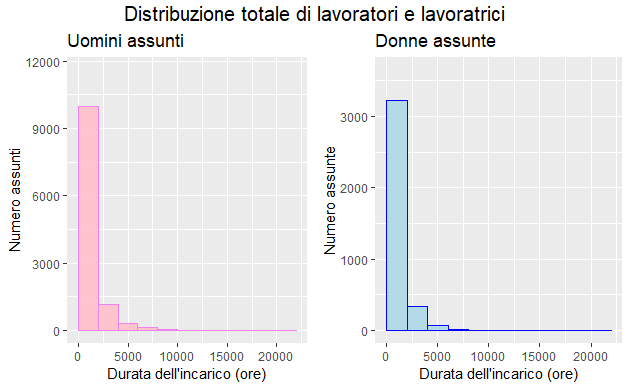

```r
h_male_total <- ggplot(data=filter(df, gender =="Male"), aes(tenure_len)) +
        geom_histogram(breaks=seq(0, 22000, by=2000),
                 col="violet",
                 fill="pink",
                 alpha = .9) +
        labs(title="Uomini assunti", x="Durata dell'incarico (ore)", y="Numero assunti") +
        ylim(c(0,11602))
h_female_total <- ggplot(data=filter(df, gender =="Female"), aes(tenure_len)) +
        geom_histogram(breaks=seq(0, 22000, by=2000),
                 col="blue",
                 fill="lightblue",
                 alpha = .9) +
        labs(title="Donne assunte", x="Durata dell'incarico (ore)", y="Numero assunte") +
        ylim(c(0,3650))
title <- textGrob("Distribuzione totale di lavoratori e lavoratrici", gp=gpar(fontsize=15, font=1))
grid.arrange(h_male_total, h_female_total,  ncol = 2, top=title)
```

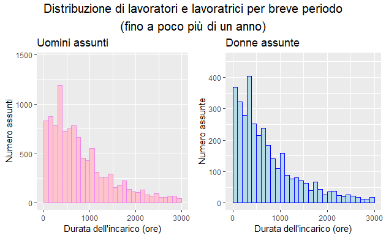

```r
h_male_low <- ggplot(data=filter(df, gender =="Male"), aes(tenure_len)) +
        geom_histogram(breaks=seq(0, 3000, by=100),
                 col="violet",
                 fill="pink",
                 alpha = .9) +
        labs(title="Uomini assunti", x="Durata dell'incarico (ore)", y="Numero assunti") +
        ylim(c(0,1450))
h_female_low <- ggplot(data=filter(df, gender =="Female"), aes(tenure_len)) +
        geom_histogram(breaks=seq(0, 3000, by=100),
                 col="blue",
                 fill="lightblue",
                 alpha = .9) +
        labs(title="Donne assunte", x="Durata dell'incarico (ore)", y="Numero assunte") +
        ylim(c(0, 456))
title <- textGrob("Distribuzione di lavoratori e lavoratrici per breve periodo\n(fino a poco più di un anno)", gp=gpar(fontsize=15, font=1))
grid.arrange(h_male_low, h_female_low,  ncol = 2, top=title)
```

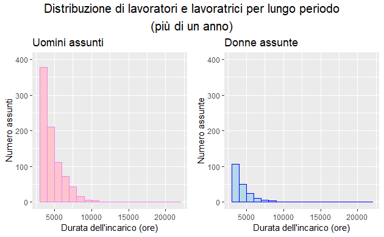

```r
h_male_high <- ggplot(data=filter(df, gender =="Male"), aes(tenure_len)) +
        geom_histogram(breaks=seq(3000, 22000, by=1000),
                 col="violet",
                 fill="pink",
                 alpha = .9) +
        labs(title="Uomini assunti", x="Durata dell'incarico (ore)", y="Numero assunti") +
        ylim(c(0,400))
h_female_high <- ggplot(data=filter(df, gender =="Female"), aes(tenure_len)) +
        geom_histogram(breaks=seq(3000, 22000, by=1000),
                 col="blue",
                 fill="lightblue",
                 alpha = .9) +
        labs(title="Donne assunte", x="Durata dell'incarico (ore)", y="Numero assunte") +
        ylim(c(0,400))
title <- textGrob("Distribuzione di lavoratori e lavoratrici per lungo periodo\n(più di un anno)", gp=gpar(fontsize=15, font=1))
grid.arrange(h_male_high, h_female_high,  ncol = 2, top=title)
```

Ripetiamo la stessa analisi condotta sui generi anche sulle diverse etnie.

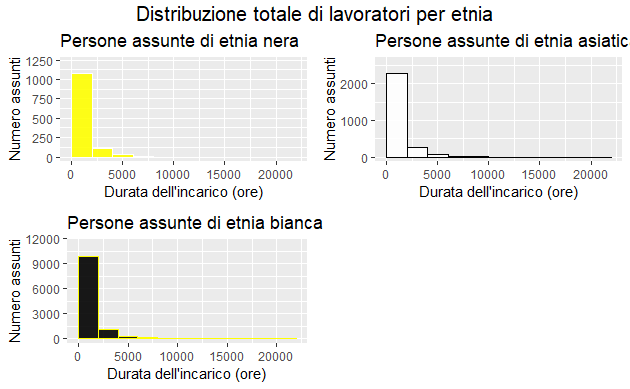

```r
h_black_total <- ggplot(data=filter(df, ethnicity=="Black"), aes(tenure_len)) +
        geom_histogram(breaks=seq(0, 22000, by=2000),
                 col="white",
                 fill="yellow",
                 alpha = .9) +
        labs(title="Persone assunte di etnia nera", x="Durata dell'incarico (ore)", y="Numero assunti") +
        ylim(c(0,1225))
h_asian_total <- ggplot(data=filter(df, ethnicity=="Asian"), aes(tenure_len)) +
        geom_histogram(breaks=seq(0, 22000, by=2000),
                 col="black",
                 fill="white",
                 alpha = .9) +
        labs(title="Persone assunte di etnia asiatica", x="Durata dell'incarico (ore)", y="Numero assunti") +
        ylim(c(0,2593))
h_white_total <- ggplot(data=filter(df, ethnicity =="White"), aes(tenure_len)) +
        geom_histogram(breaks=seq(0, 22000, by=2000),
                 col="yellow",
                 fill="black",
                 alpha = .9) +
        labs(title="Persone assunte di etnia bianca", x="Durata dell'incarico (ore)", y="Numero assunti") +
        ylim(c(0,11434))
title <- textGrob("Distribuzione totale di lavoratori per etnia", gp=gpar(fontsize=15, font=1))
grid.arrange(h_black_total, h_asian_total, h_white_total,  ncol = 2, top=title)
```

[output not shown]

```r
not_working <- dplyr::select(raw_data, tenure_len, gender, ethnicity, beauty) %>%
        filter(tenure_len == 0)
nrow(not_working)
```

[output not shown]

```r
summary(not_working$gender)
```

[output not shown]

```r
summary(not_working$ethnicity)
```

[output not shown]

```r
beauty_male <- ggplot(data=filter(df, gender =="Male"), aes(beauty_male)) +
        geom_histogram(breaks=seq(0, 100, by=5),
                 col="red",
                 fill="green",
                 alpha = .2) +
        labs(title="Uomini assunti", x="Valutazione della bellezza", y="Numero assunti") +
        ylim(c(0,10000))
beauty_female <- ggplot(data=filter(df, gender =="Female"), aes(beauty_female)) +
        geom_histogram(breaks=seq(0, 100, by=5),
                 col="red",
                 fill="green",
                 alpha = .2) +
        labs(title="Donne assunte", x="Valutazione della bellezza", y="Numero assunte") +
        ylim(c(0,10000))
grid.arrange(beauty_male, beauty_female,  ncol = 2)
```

[output not shown]

Dovremmo però vedere se i belli sono assunti per più tempo oppure no.

```r
beauty_male_not_w <- ggplot(data=filter(not_working, gender =="Male"), aes(beauty)) +
        geom_histogram(breaks=seq(0, 100, by=5),
                 col="red",
                 fill="green",
                 alpha = .2) +
        labs(title="Uomini non assunti", x="Valutazione della bellezza", y="Numero non assunti") +
        ylim(c(0,100))
beauty_female_not_w <- ggplot(data=filter(not_working, gender =="Female"), aes(beauty)) +
        geom_histogram(breaks=seq(0, 100, by=5),
                 col="red",
                 fill="green",
                 alpha = .2) +
        labs(title="Donne non assunte", x="Valutazione della bellezza", y="Numero non assunte") +
        ylim(c(0,100))
grid.arrange(beauty_male_not_w, beauty_female_not_w,  ncol = 2)
```

[output not shown]

```r
matrix_beauty_len <- dplyr::select(df, beauty, tenure_len)
plot(matrix_beauty_len)
```

[output not shown]

```r
females_working <- dplyr::select(df, beauty, tenure_len, gender, n_prev_tenures) %>%
        filter (gender == "Female")
nrow(females_working)
matrix_beauty_len_female <- dplyr::select(females_working, beauty, tenure_len)
plot(matrix_beauty_len_female)
```

[output not shown]

```r
males_working <- dplyr::select(df, beauty, tenure_len, gender) %>%
        filter (gender == "Male")
matrix_beauty_len_male <- dplyr::select(males_working, beauty, tenure_len)
plot(matrix_beauty_len_male)
```

[output not shown]

```r
matrix_age_len <- dplyr::select(df, age, tenure_len)
plot(matrix_age_len)
```

[output not shown]

```r
matrix_followers_len <- dplyr::select(df, n_followers, tenure_len)
plot(matrix_followers_len)
```

[output not shown]

```r
male_prev_pos <- ggplot(data=filter(df, gender =="Male"), aes(n_prev_tenures)) +
        geom_histogram(breaks=seq(1, 10, by=1),
                 col="red",
                 fill="green",
                 alpha = .2) +
        labs(title="Uomini assunti", x="Numero di incarichi precedenti", y="Uomini") +
        ylim(c(0,10000))
female_prev_pos <- ggplot(data=filter(df, gender =="Female"), aes(n_prev_tenures)) +
        geom_histogram(breaks=seq(1, 10, by=1),
                 col="red",
                 fill="green",
                 alpha = .2) +
        labs(title="Donne assunte", x="Numero di incarichi precedenti", y="Donne") +
        ylim(c(0,10000))
grid.arrange(male_prev_pos, female_prev_pos,  ncol = 2)
```

[output not shown]

```r
matrix_beauty_prev <- dplyr::select(females_working, beauty, n_prev_tenures)
plot(matrix_beauty_prev)
```

[output not shown]

```r
plot(df$smile, df$tenure_len, main = "Correlazione tra il sorriso mostrato in foto e la lunghezza dell'incarico ottenuto", col = "Red")
```

[output not shown]